# Assignment 8

**Student Name:** Sasagawa Koki  
**Student ID:** 999054646

## Assignment 8: Gene Networks 2

This should be a knittable .Rmd file. Include this file, a .pdf and a .html when you turn in the assignment.

```r
# be sure to change the path
cities <- read.table("./us_cities.txt", sep = "\t", header = TRUE)
rownames(cities) <- cities$X #make first column the rownames
cities <- cities[,-1] #remove first column
cities <- as.matrix(cities) #convert to matrix
cities # print matrix
```

```
##       BOS   NY   DC  MIA  CHI  SEA   SF   LA  DEN
## BOS     0  206  429 1504  963 2976 3095 2979 1949
## NY    206    0  233 1308  802 2815 2934 2786 1771
## DC    429  233    0 1075  671 2684 2799 2631 1616
## MIA  1504 1308 1075    0 1329 3273 3053 2687 2037
## CHI   963  802  671 1329    0 2013 2142 2054  996
## SEA  2976 2815 2684 3273 2013    0  808 1131 1307
## SF   3095 2934 2799 3053 2142  808    0  379 1235
## LA   2979 2786 2631 2687 2054 1131  379    0 1059
## DEN  1949 1771 1616 2037  996 1307 1235 1059    0
```

Imagine the airline had only 1500 miles. Putting a constraint on our city networks lets create an adjacency matrix.

```r
cities_mat <- cities < 1500 # leave original matrix intact
diag(cities_mat) <- 0 # we do not have to fly within each of cities :)
cities_mat # check out the adjacency matrix
```

```
##      BOS NY DC MIA CHI SEA SF LA DEN
## BOS    0  1  1   0   1   0  0  0   0
## NY     1  0  1   1   1   0  0  0   0
## DC     1  1  0   1   1   0  0  0   0
## MIA    0  1  1   0   1   0  0  0   0
## CHI    1  1  1   1   0   0  0  0   1
## SEA    0  0  0   0   0   0  1  1   1
## SF     0  0  0   0   0   1  0  1   1
## LA     0  0  0   0   0   1  1  0   1
## DEN    0  0  0   0   1   1  1  1   0
```

**Exercise 1:** Based on this 0 or 1 representation of our network, what city is the most highly connected? *Hint: sum the values down a column OR across a row for each city*

```r
#The number 1 indicates by row, 2 indicates by column
#The apply function allows us to apply a function to each row or column of the matrix
apply(cities_mat, 1, sum)
```

```
## BOS   NY   DC  MIA  CHI  SEA   SF   LA  DEN
##    3    4    4    3    5    3    3    3    4
```

> The city that is most connected is Chicago.

What if you were to extend the range to 2000 miles in the above code. Does the highest connected city change? If so explain.

```r
cities_mat2 <- cities < 2000 # leave original matrix intact
diag(cities_mat2) <- 0 # we do not have to fly within each of cities :)
cities_mat2 # check out the adjacency matrix
```

```
##      BOS NY DC MIA CHI SEA SF LA DEN
## BOS    0  1  1   1   1   0  0  0   1
## NY     1  0  1   1   1   0  0  0   1
## DC     1  1  0   1   1   0  0  0   1
## MIA    1  1  1   0   1   0  0  0   0
## CHI    1  1  1   1   0   0  0  0   1
## SEA    0  0  0   0   0   0  1  1   1
## SF     0  0  0   0   0   1  0  1   1
## LA     0  0  0   0   0   1  1  0   1
## DEN    1  1  1   0   1   1  1  1   0
```

```r
#calculate the sum of 1's
apply(cities_mat2, 1, sum)
```

```
## BOS   NY   DC  MIA  CHI  SEA   SF   LA  DEN
##    5    5    5    4    5    3    3    3    7
```

> The city that is most connected is Denver. Changing the limit of the range can change the result as it becomes less restrictive. The extended limit can now capture more cities that could possibly be connected.

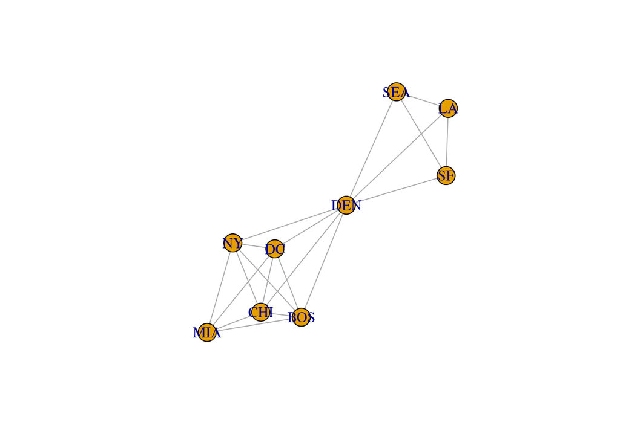

```r
library(igraph) # load package
# make sure to use the 2000 mile distance cutoff
cities_graph2 <- graph.adjacency(cities_mat2, mode = "undirected")
plot.igraph(cities_graph2)
```

**Exercise 2:** What is the total number of nodes in the plot? What is the total number of edges in the plot?

**Exercise 3:** Re-calculate the adjacency matrix with the cutoff value at 2300. Calculate the number of edges using the following code. What do you get?

```r
cities_mat3 <- cities < 2300 # leave original matrix intact
diag(cities_mat3) <- 0 # we do not have to fly within each of cities :)
cities_mat3 # check out the adjacency matrix
```

```
##      BOS NY DC MIA CHI SEA SF LA DEN
## BOS    0  1  1   1   1   0  0  0   1
## NY     1  0  1   1   1   0  0  0   1
## DC     1  1  0   1   1   0  0  0   1
## MIA    1  1  1   0   1   0  0  0   1
## CHI    1  1  1   1   0   1  1  1   1
## SEA    0  0  0   0   1   0  1  1   1
## SF     0  0  0   0   1   1  0  1   1
## LA     0  0  0   0   1   1  1  0   1
## DEN    1  1  1   1   1   1  1  1   0
```

```r
sum(cities_mat3)/2 # divide by 2 because the matrix has 2 values for each edge
```

```
## [1] 24
```

> Using the new limit of 2300 miles, we get a total of 24 edges.

**(Gene1)–(1)–(Gene2)**

**(Gene2)–(0)–(Gene3)**

**(Gene1)–(0)–(Gene3)**

**(Gene3)–(0)–(Gene4)**

```r
genes <- read.table("voom_transform_brassica.csv", sep = ",", header = TRUE)
#Check
head(genes)
```

[output not shown]

[output cut: 57 more lines]

```
## Bra000007         -0.5348966           -1.1664544        12.68364
##           R500_NDP_2_PETIOLE R500_NDP_2_SILIQUE R500_NDP_3_INTERNODE
## Bra000002          -1.995283          1.1297954           -0.1758693
## Bra000003           5.353445          5.5221128            5.2016511
## Bra000004          -1.995283          1.1297954           -0.6612961
## Bra000005           6.271503          5.6142310            6.8747568
## Bra000006           4.799133          5.3482189            4.4597193
## Bra000007          -1.995283         -0.2487163           -2.9832242
##           R500_NDP_3_LEAF R500_NDP_3_PETIOLE R500_NDP_3_SILIQUE
## Bra000002        11.11458         -2.9267608         -0.4676259
## Bra000003        11.11458          5.3400257          5.1130365
## Bra000004        11.11458         -0.6048327         -0.1050558
## Bra000005        11.11458          6.3516886          5.6408986
## Bra000006        11.11458          4.4130892          5.9800478
## Bra000007        11.11458         -0.1194059          0.9729467
```

```r
genes <- genes[,-c(38,42,46)] # remove questionable library columns
DE_genes <- read.table("DEgenes_GxE.csv", sep = ",")
#Check
head(DE_genes)
```

```
##               logFC   logCPM        LR       PValue          FDR
## Bra010821  6.657165 6.040918 153.15544 3.542436e-35 8.513891e-31
## Bra033034 -4.639893 6.611694  71.26078 3.129960e-17 3.761273e-13
## Bra035334 -4.142456 4.665331  68.34729 1.370938e-16 1.098304e-12
## Bra003598 -4.893648 3.900122  54.16121 1.846974e-13 1.109755e-09
## Bra016182  7.714360 6.330237  49.61407 1.871665e-12 8.996719e-09
## Bra013164  4.098373 9.329089  47.94483 4.383823e-12 1.756013e-08
```

```r
DE_gene_names <- rownames(DE_genes)
GxE_counts <- as.data.frame(genes[DE_gene_names,])
genes_cor <- cor(t(GxE_counts)) # calculate the correlation between all gene pairs
```

**Exercise 5:**

**a** Create an adjacency matrix called `genes_adj85` for the genes use a cutoff of abs(correlation) > 0.85. Remember to set the diagonal of the adjacency matrix to 0. Create a second adjacency matrix `genes_adj95` using a cutoff of abs(correlation) > 0.95. See above code for cities.

```r
genes_adj85 <- genes_cor > 0.85 # leave original matrix intact
diag(genes_adj85) <- 0
head(genes_adj85) # check out the adjacency matrix
```

[output not shown]

[output cut: 253 more lines]

```
## Bra013164         0         0         0         1         0         0
##           Bra034140 Bra000534 Bra012597 Bra028400 Bra030116 Bra004581
## Bra010821         0         0         0         0         0         0
## Bra033034         0         0         0         0         0         0
## Bra035334         0         0         0         0         0         0
## Bra003598         0         0         0         0         0         0
## Bra016182         0         0         0         0         0         0
## Bra013164         0         0         0         0         0         0
##           Bra009182 Bra101149 Bra027206 Bra006173
## Bra010821         0         0         0         0
## Bra033034         0         0         0         0
## Bra035334         0         0         0         0
## Bra003598         0         0         0         0
## Bra016182         0         0         0         0
## Bra013164         0         0         0         0
```

```r
genes_adj95 <- genes_cor > 0.95
diag(genes_adj95) <- 0
head(genes_adj95) # check out the adjacency matrix
```

[output not shown]

[output cut: 253 more lines]

```
## Bra013164         0         0         0         0         0         0
##           Bra034140 Bra000534 Bra012597 Bra028400 Bra030116 Bra004581
## Bra010821         0         0         0         0         0         0
## Bra033034         0         0         0         0         0         0
## Bra035334         0         0         0         0         0         0
## Bra003598         0         0         0         0         0         0
## Bra016182         0         0         0         0         0         0
## Bra013164         0         0         0         0         0         0
##           Bra009182 Bra101149 Bra027206 Bra006173
## Bra010821         0         0         0         0
## Bra033034         0         0         0         0
## Bra035334         0         0         0         0
## Bra003598         0         0         0         0
## Bra016182         0         0         0         0
## Bra013164         0         0         0         0
```

**b** Now we can do some calculations. If our cutoff is 0.85, how many edges do we have in our 255 node network? What if we increase our cutoff to 0.95?

```r
#Calculating the number of edges
sum(genes_adj85)/2 # divide by 2 because the matrix has 2 values for each edge
```

```
## [1] 460
```

```r
sum(genes_adj95)/2
```

```
## [1] 9
```

> Using the .85 cut off we get 460 edges. Increasing the cut off drastically reduced the number of edges we get to 9.

**Exercise 6:** Use the following code to plot our networks using different thresholds for connectivity. What patterns do you see in the visualization of this data? *Note: the second plot will take a while to render*

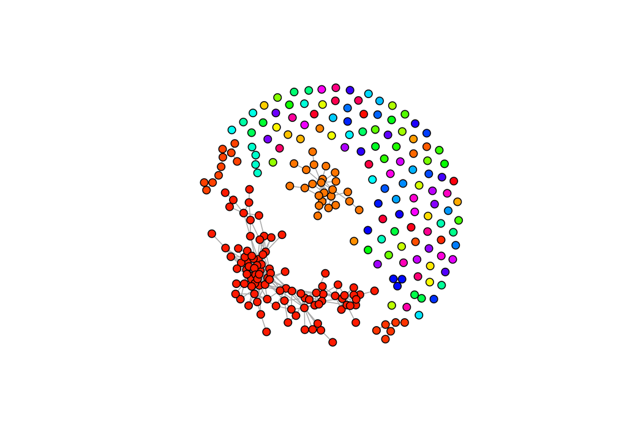

```r
#Graph 0.85 cutoff
gene_graph85 <- graph.adjacency(genes_adj85, mode = "undirected") #convert adjacency to graph
comps <- clusters(gene_graph85)$membership                        #define gene cluster membership
colbar <- rainbow(max(comps)+1)                                   #define colors
V(gene_graph85)$color <- colbar[comps+1]                          #assign colors to nodes
plot(gene_graph85, layout = layout.fruchterman.reingold, vertex.size = 6, vertex.label = NA)
```

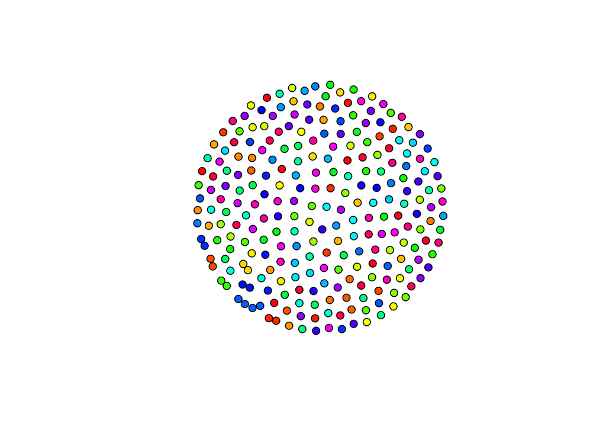

```r
#Graph 0.95 cutoff
gene_graph95 <- graph.adjacency(genes_adj95, mode = "undirected") #convert adjacency to graph
comps2 <- clusters(gene_graph95)$membership                        #define gene cluster membership
colbar2 <- rainbow(max(comps2)+1)                                   #define colors
V(gene_graph95)$color <- colbar2[comps2+1]                          #assign colors to nodes
plot(gene_graph95, layout = layout.fruchterman.reingold, vertex.size = 6, vertex.label = NA)
```

**Exercise 7:** Use the following code to answer these two questions: In gene_graph85, what is the total graph density? In gene_graph85, what is the average path length?

```r
graph.density(gene_graph85)
```

```
## [1] 0.01420411
```

```r
average.path.length(gene_graph85)
```

```
## [1] 3.478598
```

> The total graph density is 0.01420411 The average path length is 3.478598

```r
gene_graph85 <- graph.adjacency(genes_adj85, mode = "undirected")
distMatrix <- shortest.paths(gene_graph85, v = V(gene_graph85), to = V(gene_graph85))
head(distMatrix)[,1:7]
```

```
##           Bra010821 Bra033034 Bra035334 Bra003598 Bra016182 Bra013164
## Bra010821         0       Inf       Inf       Inf       Inf       Inf
## Bra033034       Inf         0       Inf       Inf       Inf         4
## Bra035334       Inf       Inf         0       Inf       Inf       Inf
## Bra003598       Inf       Inf       Inf         0       Inf       Inf
## Bra016182       Inf       Inf       Inf       Inf         0       Inf
## Bra013164       Inf         4       Inf       Inf       Inf         0
##           Bra009406
## Bra010821       Inf
## Bra033034         6
## Bra035334       Inf
## Bra003598       Inf
## Bra016182       Inf
## Bra013164         3
```

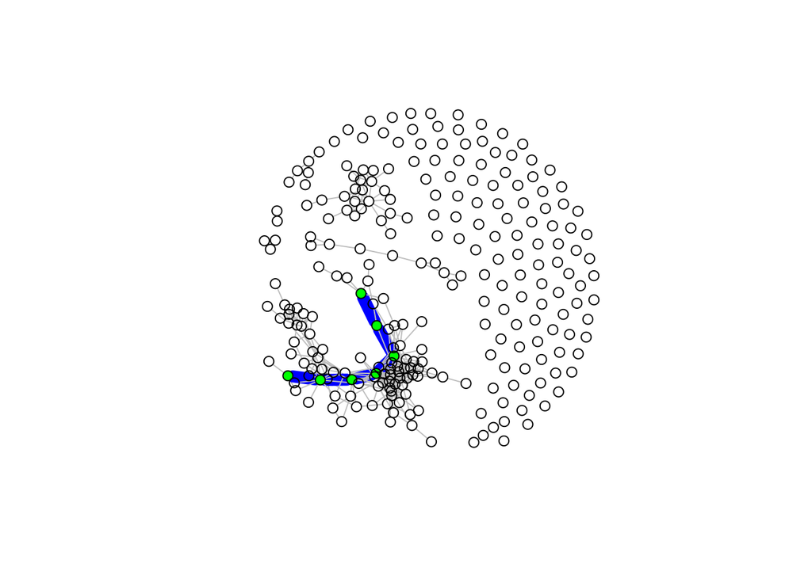

```r
pl <- get.shortest.paths(gene_graph85, 2, 7)$vpath[[1]] # pull paths between node 2 and 7

V(gene_graph85)[pl]$color <- paste("green")          # define node color
E(gene_graph85)$color <- paste("grey")               # define default edge color
E(gene_graph85, path = pl)$color <- paste("blue")    # define edge color
E(gene_graph85, path = pl)$width <- 10               # define edge width
plot(gene_graph85, layout = layout.fruchterman.reingold, vertex.size = 6, vertex.label = NA)
```

**Exercise 8:** Using what you know about graphs, repeat your analysis of the smaller cities matrix. Show your code to answer these questions. What is the graph density of the cities network with a 1500 mile flight range?

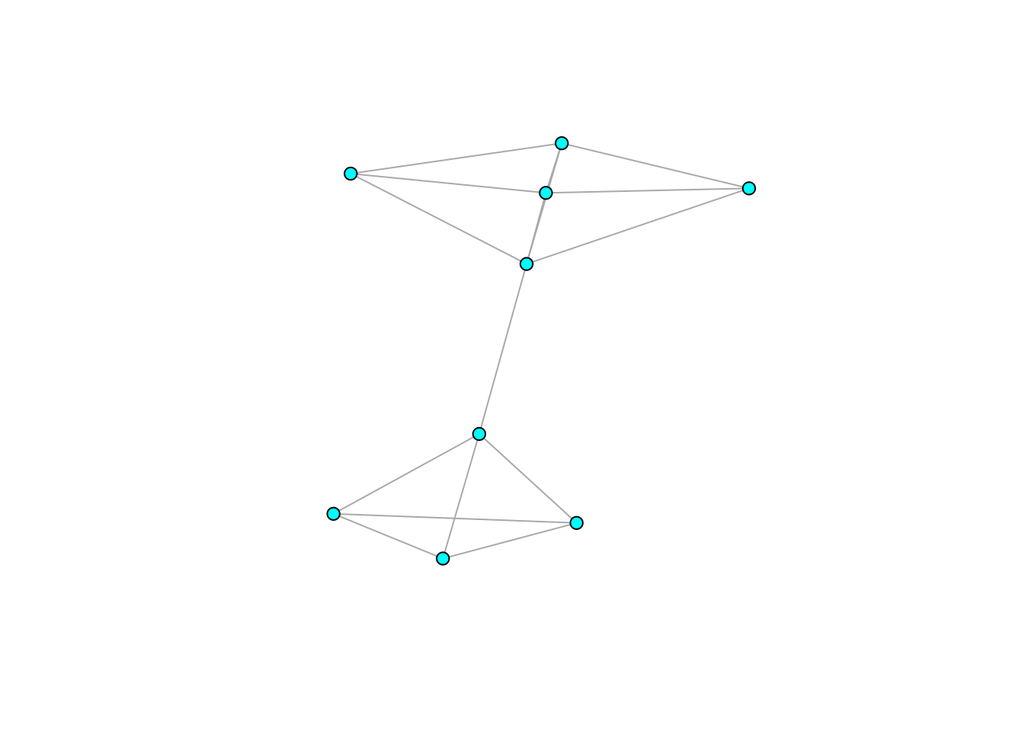

```r
#Graph cities with a 1500 mile flight rang
cities_mat_graph <- graph.adjacency(cities_mat, mode = "undirected") #convert adjacency to graph
comps3 <- clusters(cities_mat_graph)$membership                        #define gene cluster membership
colbar3 <- rainbow(max(comps3)+1)                                   #define colors
V(cities_mat_graph)$color <- colbar3[comps3+1]                          #assign colors to nodes
plot(cities_mat_graph, layout = layout.fruchterman.reingold, vertex.size = 6, vertex.label = NA)
```

```r
graph.density(cities_mat_graph)
```

```
## [1] 0.4444444
```

> The graph densities of the cities with a 1500 mile flight range is 0.4444444

What is the average path length of the cities network with a 1500 mile flight range?

```r
average.path.length(cities_mat_graph)
```

```
## [1] 1.888889
```

> The average path length of the cities network with a 1500 mile flight range is 1.888889

Find the shortest path between SEA and DC with 1500 mile flight range. Graph it.

```r
cities_mat_graph <- graph.adjacency(cities_mat, mode = "undirected")
cityDistMatrix <- shortest.paths(cities_mat_graph, v = V(cities_mat_graph), to = V(cities_mat_graph))
cityDistMatrix
```

```
##     BOS NY DC MIA CHI SEA SF LA DEN
## BOS   0  1  1   2   1   3  3  3   2
## NY    1  0  1   1   1   3  3  3   2
## DC    1  1  0   1   1   3  3  3   2
## MIA   2  1  1   0   1   3  3  3   2
## CHI   1  1  1   1   0   2  2  2   1
## SEA   3  3  3   3   2   0  1  1   1
## SF    3  3  3   3   2   1  0  1   1
## LA    3  3  3   3   2   1  1  0   1
## DEN   2  2  2   2   1   1  1  1   0
```

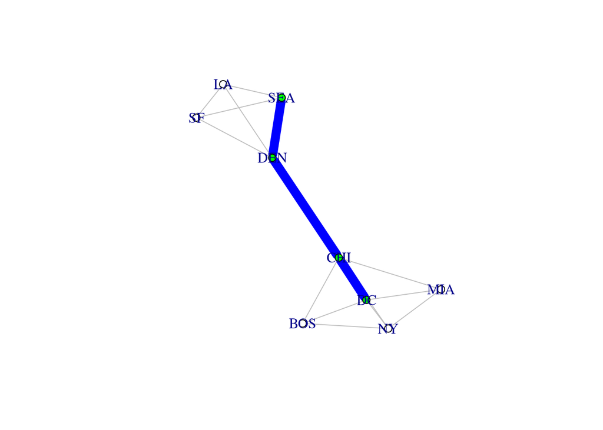

```r
p2 <- get.shortest.paths(cities_mat_graph, "SEA", "DC")$vpath[[1]] # pull paths between SEA and DC

V(cities_mat_graph)[p2]$color <- paste("green")          # define node color
E(cities_mat_graph)$color <- paste("grey")               # define default edge color
E(cities_mat_graph, path = p2)$color <- paste("blue")    # define edge color
E(cities_mat_graph, path = p2)$width <- 10               # define edge width
plot(cities_mat_graph, layout = layout.fruchterman.reingold, vertex.size = 6)
```

> The shortest past from SEA to DC is SEA –> DEN –> CHI –> DC.

Find the shortest path between SEA and DC with 2300 mile flight range. Graph it.

```r
cities_mat3_graph <- graph.adjacency(cities_mat3, mode = "undirected")
cityDistMatrix2 <- shortest.paths(cities_mat3_graph, v = V(cities_mat3_graph), to = V(cities_mat3_graph))
cityDistMatrix2
```

```
##     BOS NY DC MIA CHI SEA SF LA DEN
## BOS   0  1  1   1   1   2  2  2   1
## NY    1  0  1   1   1   2  2  2   1
## DC    1  1  0   1   1   2  2  2   1
## MIA   1  1  1   0   1   2  2  2   1
## CHI   1  1  1   1   0   1  1  1   1
## SEA   2  2  2   2   1   0  1  1   1
## SF    2  2  2   2   1   1  0  1   1
## LA    2  2  2   2   1   1  1  0   1
## DEN   1  1  1   1   1   1  1  1   0
```

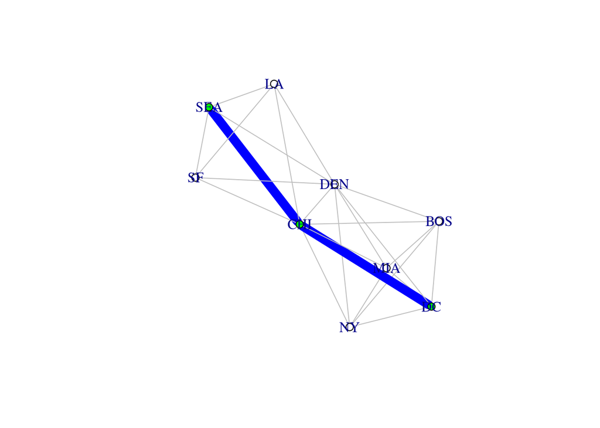

```r
p3 <- get.shortest.paths(cities_mat3_graph, "SEA", "DC")$vpath[[1]] # pull paths between SEA and DC

V(cities_mat3_graph)[p3]$color <- paste("green")          # define node color
E(cities_mat3_graph)$color <- paste("grey")               # define default edge color
E(cities_mat3_graph, path = p3)$color <- paste("blue")    # define edge color
E(cities_mat3_graph, path = p3)$width <- 10               # define edge width
plot(cities_mat3_graph, layout = layout.fruchterman.reingold, vertex.size = 6)
```

> The shortest distance is SEA –> CHI –> DC. The route does not stop at DEN as the planes have more gas now, it is able to go directly from SEA to CHI.